# CSC 578 Final

## Kaggle Competition Notebook

### Brandon Polk

#### Kaggle Name: Brandon Polk

## Library Imports (same as tutorial)

```python
import os
import datetime

import IPython
import IPython.display
import matplotlib as mpl
import matplotlib.pyplot as plt
import numpy as np
import pandas as pd
import seaborn as sns
import tensorflow as tf

mpl.rcParams['figure.figsize'] = (8, 6)
mpl.rcParams['axes.grid'] = False
```

## Data: Minneapolis/St.Paul Traffic Time Series

This notebook uses a [traffic time series dataset](https://archive.ics.uci.edu/ml/machine-learning-databases/00492/Metro_Interstate_Traffic_Volume.csv.gz) recorded by the [John Hogue Social Data Science & General Mills](https://archive.ics.uci.edu/ml/datasets/Metro+Interstate+Traffic+Volume#).

Hourly Interstate 94 Westbound traffic volume for MN DoT ATR station 301, roughly midway between Minneapolis and St Paul, MN. Hourly weather features and holidays included for impacts on traffic volume. 9 attributes, 48,000+ samples

**holiday-** Categorical US National holidays plus regional holiday, Minnesota State Fair  
**temp-** Numeric Average temp in kelvin  
**rain_1h-** Numeric Amount in mm of rain that occurred in the hour  
**snow_1h-** Numeric Amount in mm of snow that occurred in the hour  
**clouds_all-** Numeric Percentage of cloud cover  
**weather_main-** Categorical Short textual description of the current weather  
**weather_description-** Categorical Longer textual description of the current weather  
**date_time-** DateTime Hour of the data collected in local CST time  
**traffic_volume**- Numeric Hourly I-94 ATR 301 reported westbound traffic volume

Downloading data

```python
zip_path = tf.keras.utils.get_file(
    origin='https://archive.ics.uci.edu/ml/machine-learning-databases/00492/Metro_Interstate_Traffic_Volume.csv.gz',
    fname='Metro_Interstate_Traffic_Volume.csv.gz',
    cache_dir='/content', cache_subdir='sample_data')
# colab doesn't know how to automatically gunzip a file
!gunzip sample_data/Metro_Interstate_Traffic_Volume.csv.gz
csv_path, _ = os.path.splitext(zip_path)  # just strip off the .gz
csv_path                                  # should be '/content/sample_data/Metro_Interstate_Traffic_Volume.csv'
```

```
Downloading data from https://archive.ics.uci.edu/ml/machine-learning-databases/00492/Metro_Interstate_Traffic_Volume.csv.gz
gzip: sample_data/Metro_Interstate_Traffic_Volume.csv already exists; do you wish to overwrite (y or n)? y
```

```
'/content/sample_data/Metro_Interstate_Traffic_Volume.csv'
```

Creating dataframe from csv data and collecting the date times of the samples

```python
df = pd.read_csv(csv_path)

date_time = pd.to_datetime(df.pop('date_time'), format='%Y-%m-%d %H:%M:%S')
```

## Data Exploration

Let's take a glance at the data. Here are the first few rows:

```python
df.head()
```

|  | holiday | temp | rain_1h | snow_1h | clouds_all | weather_main | weather_description | traffic_volume |
| --- | --- | --- | --- | --- | --- | --- | --- | --- |
| 0 | None | 288.28 | 0.0 | 0.0 | 40 | Clouds | scattered clouds | 5545 |
| 1 | None | 289.36 | 0.0 | 0.0 | 75 | Clouds | broken clouds | 4516 |
| 2 | None | 289.58 | 0.0 | 0.0 | 90 | Clouds | overcast clouds | 4767 |
| 3 | None | 290.13 | 0.0 | 0.0 | 90 | Clouds | overcast clouds | 5026 |
| 4 | None | 291.14 | 0.0 | 0.0 | 75 | Clouds | broken clouds | 4918 |

```python
#5-Point Summary and Frequency information
df.describe(include='all').transpose()
```

|  | count | unique | top | freq | mean | std | min | 25% | 50% | 75% | max |
| --- | --- | --- | --- | --- | --- | --- | --- | --- | --- | --- | --- |
| holiday | 48204 | 12 | None | 48143 | NaN | NaN | NaN | NaN | NaN | NaN | NaN |
| temp | 48204 | NaN | NaN | NaN | 281.206 | 13.3382 | 0 | 272.16 | 282.45 | 291.806 | 310.07 |
| rain_1h | 48204 | NaN | NaN | NaN | 0.334264 | 44.7891 | 0 | 0 | 0 | 0 | 9831.3 |
| snow_1h | 48204 | NaN | NaN | NaN | 0.000222388 | 0.00816761 | 0 | 0 | 0 | 0 | 0.51 |
| clouds_all | 48204 | NaN | NaN | NaN | 49.3622 | 39.0158 | 0 | 1 | 64 | 90 | 100 |
| weather_main | 48204 | 11 | Clouds | 15164 | NaN | NaN | NaN | NaN | NaN | NaN | NaN |
| weather_description | 48204 | 38 | sky is clear | 11665 | NaN | NaN | NaN | NaN | NaN | NaN | NaN |
| traffic_volume | 48204 | NaN | NaN | NaN | 3259.82 | 1986.86 | 0 | 1193 | 3380 | 4933 | 7280 |

Intersting things to note here:  
1) Temperature is measured in kelvins, so a temp of 0 is absolute zero. Absolute zero is not a possible temperature in this context, so any sample with this value is likely missing data and must be dealt with appropriately.

2) There is a severe outlier in rain_1h. It has a max value of 9831.3 mm which would be an excessive amount of rainfall in a single hour, far beyond what would be considered possible.

3) There are several categorical variables that may need to be transformed into numerical representations to be used in the predictive RNN model.

These issues will be rectified before we use the data in any models.

#### Fixing temp outlier

The 0 temp values within the data will be replaced by the average temps at that hour in the rest of the data

```python
#Index of outlier temp values
temp0= df[df['temp']== 0].index
temp0
```

```
Int64Index([11898, 11899, 11900, 11901, 11946, 11947, 11948, 11949, 11950,
            11951],
           dtype='int64')
```

```python
#Gather all date times from samples with a recorded temperature > 0
dt_warm= date_time.iloc[[i for i in date_time.index if i not in temp0]]
```

```python
#Replacing temp 0 values with mean of temp at that hour throughout the rest of the data
#Only samnples with a recorded temperature above zero are used to calculate the mean

#For every sample with a recorded temperature of 0, its temp value is replaced with the mean value of temp for all samples at the same hour with a recorded temp > 0
for i in temp0:
  h= date_time.iloc[i].hour
  m= df.iloc[dt_warm[dt_warm.dt.hour== h].index]['temp'].mean()
  df.at[i,'temp']= m
```

#### Fixing rain outlier

The 1 rain outlier within the data will be replaced with the average amount of rain for that hour throughout the rest of the data

```python
#Index of outlier rain value
df[df['rain_1h']== 9831.3].index
```

```
Int64Index([24872], dtype='int64')
```

```python
# Findind the timestamp hour of the rain outlier
date_time.iloc[24872].hour
```

```
17
```

```python
#Finding the mean of the rain value for all other data collected at hour 17
dt_rain= date_time[date_time.index!=24872]
h17_rain= df.iloc[dt_rain[dt_rain.dt.hour== 17].index]['rain_1h'].mean()

#Replacing the outlier
df.at[24872, 'rain_1h']= h17_rain
```

The obvious outliers have been addressed:

```python
df.describe().T
```

|  | count | mean | std | min | 25% | 50% | 75% | max |
| --- | --- | --- | --- | --- | --- | --- | --- | --- |
| temp | 48204.0 | 281.263713 | 12.708317 | 243.39 | 272.19 | 282.45 | 291.806 | 310.07 |
| rain_1h | 48204.0 | 0.130315 | 1.003368 | 0.00 | 0.00 | 0.00 | 0.000 | 55.63 |
| snow_1h | 48204.0 | 0.000222 | 0.008168 | 0.00 | 0.00 | 0.00 | 0.000 | 0.51 |
| clouds_all | 48204.0 | 49.362231 | 39.015750 | 0.00 | 1.00 | 64.00 | 90.000 | 100.00 |
| traffic_volume | 48204.0 | 3259.818355 | 1986.860670 | 0.00 | 1193.00 | 3380.00 | 4933.000 | 7280.00 |

#### Visualizing features over time

Temp

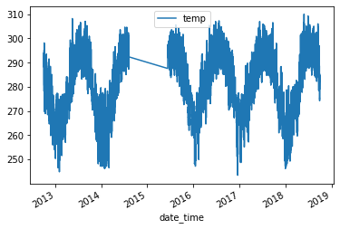

```python
#Visualizing temp over time
plot_cols = ['temp']
plot_features = df[plot_cols]
plot_features.index = date_time
_ = plot_features.plot()
```

Based on this time plot, there appears to be a notable gap in the data spanning from dates in 2014 thru 2015. This missing/invalid data may cause issues in model performance later on.

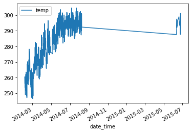

```python
# Closer look at the data gap
plot_cols = ['temp']
plot_features = df[plot_cols][12000:16000]
plot_features.index = date_time[12000:16000]
_ = plot_features.plot(subplots=True)
```

The gap in data appears to span from 2014-08 to 2015-06

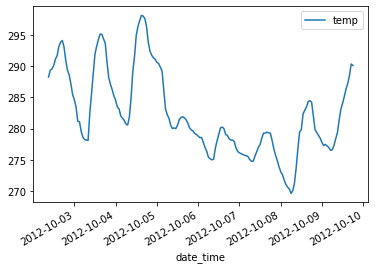

```python
# Closer look at temp data (1 week)
plot_cols = ['temp']
plot_features = df[plot_cols][:168]
plot_features.index = date_time[:168]
_ = plot_features.plot(subplots=True)
```

As expected, the temperature fluctuates from highs to lows in a regular pattern throughout the day.

Rain_1h

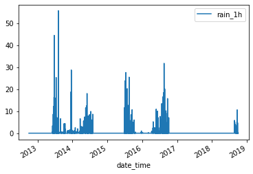

```python
#Visualizing rain_1h over time
plot_cols = ['rain_1h']
plot_features = df[plot_cols]
plot_features.index = date_time
_ = plot_features.plot()
```

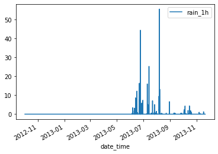

```python
# Closer look at portion of rain_1h
plot_cols = ['rain_1h']
plot_features = df[plot_cols][:10000]
plot_features.index = date_time[:10000]
_ = plot_features.plot(subplots=True)
```

The rain_1h data appears to have some inconsistancies. While yearly rainfall should vary from year to year, there one would expect there to be some general pattern of seasonal rainfall. While there is some pattern, rainfall tends to happen towards the middle and later half of the year, there is a notable lack of recorded rainfall that spans several years, including the period of missing data noted earlier. The data collection for this attribute may have been inconsistent over time.

Snow_1h

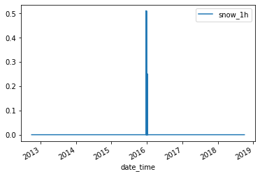

```python
#Visualizing snow_1h over time
plot_cols = ['snow_1h']
plot_features = df[plot_cols]
plot_features.index = date_time
_ = plot_features.plot()
```

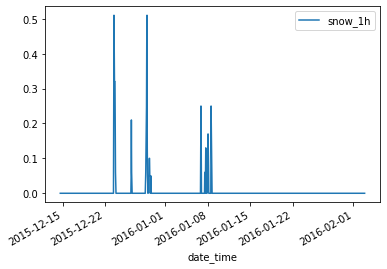

```python
# Closer look at portion of snow_1h
plot_cols = ['snow_1h']
plot_features = df[plot_cols][20000:21000]
plot_features.index = date_time[20000:21000]
_ = plot_features.plot(subplots=True)
```

Again there appears to be a significant lack of data collected for snowfall. Given that this data was collected in the minneapolis/st.paul region, it is highly unlikely that there was not more snowfall recorded over the period of time for which we have data. Whether or not this variable is ultimately included in the model will depend on its performance.

Clouds_all

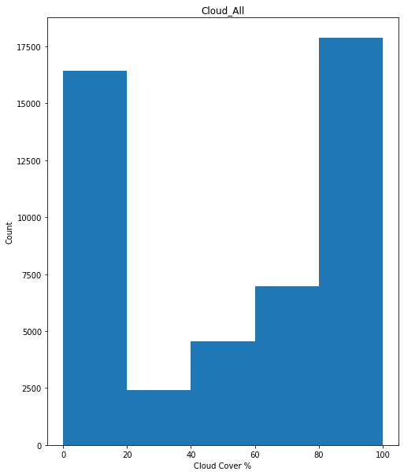

```python
#Histogram showing distribution of cloud_all variable
plt.figure(figsize= (8,10))
plt.hist(df['clouds_all'], bins=5)
plt.xlabel('Cloud Cover %')
plt.ylabel('Count')
plt.title('Cloud_All')
plt.show()
```

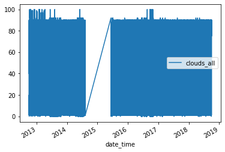

```python
#Visualizing clouds_all over time
plot_cols = ['clouds_all']
plot_features = df[plot_cols]
plot_features.index = date_time
_ = plot_features.plot()
```

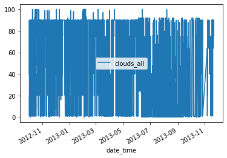

```python
# Closer look at portion of clouds_all
plot_cols = ['clouds_all']
plot_features = df[plot_cols][:10000]
plot_features.index = date_time[:10000]
_ = plot_features.plot(subplots=True)
```

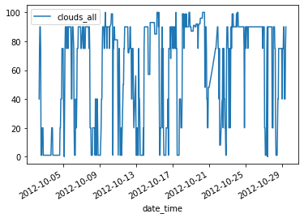

```python
# Closer look at portion of clouds_all (1 month)
plot_cols = ['clouds_all']
plot_features = df[plot_cols][:744]
plot_features.index = date_time[:744]
_ = plot_features.plot(subplots=True)
```

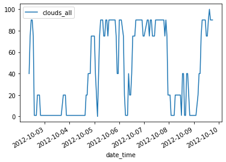

```python
# Closer look at portion of clouds_all (1 week)
plot_cols = ['clouds_all']
plot_features = df[plot_cols][:168]
plot_features.index = date_time[:168]
_ = plot_features.plot(subplots=True)
```

Traffic_volume

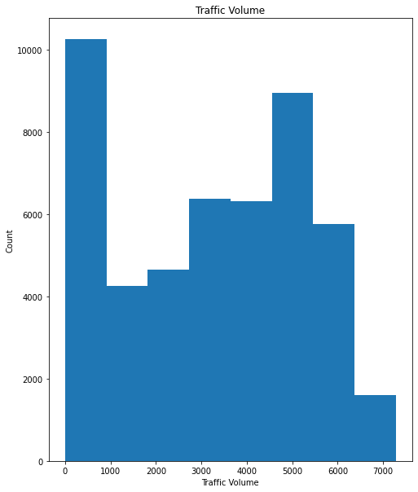

```python
#Histogram showing distribution of traffic_volume variable
plt.figure(figsize= (8,10))
plt.hist(df['traffic_volume'], bins=8)
plt.xlabel('Traffic Volume')
plt.ylabel('Count')
plt.title('Traffic Volume')
plt.show()
```

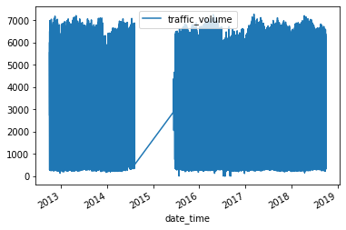

```python
#Traffic Volume over time
plot_cols = ['traffic_volume']
plot_features = df[plot_cols]
plot_features.index = date_time
_ = plot_features.plot(subplots=True)
```

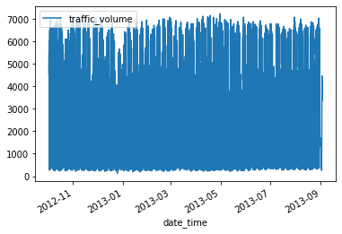

```python
#A closer look at traffic volume (1 year)
plot_cols = ['traffic_volume']
plot_features = df[plot_cols][:8760]
plot_features.index = date_time[:8760]
_ = plot_features.plot(subplots=True)
```

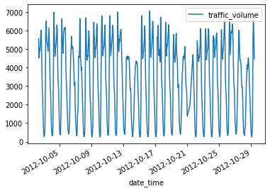

```python
#A closer look at traffic volume (1 month)
plot_cols = ['traffic_volume']
plot_features = df[plot_cols][:744]
plot_features.index = date_time[:744]
_ = plot_features.plot(subplots=True)
```

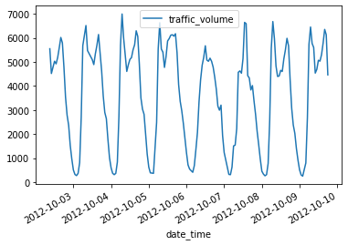

```python
#A closer look at traffic volume (1 week)
plot_cols = ['traffic_volume']
plot_features = df[plot_cols][:168]
plot_features.index = date_time[:168]
_ = plot_features.plot(subplots=True)
```

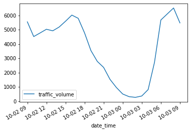

```python
#A closer look at traffic volume (1 day)
plot_cols = ['traffic_volume']
plot_features = df[plot_cols][:24]
plot_features.index = date_time[:24]
_ = plot_features.plot(subplots=True)
```

#### Exploring Categorical Data: Holiday, Weather_main, Weather_description

```python
df.describe(include='all').transpose()
```

|  | count | unique | top | freq | mean | std | min | 25% | 50% | 75% | max |
| --- | --- | --- | --- | --- | --- | --- | --- | --- | --- | --- | --- |
| holiday | 48204 | 12 | None | 48143 | NaN | NaN | NaN | NaN | NaN | NaN | NaN |
| temp | 48204 | NaN | NaN | NaN | 281.264 | 12.7083 | 243.39 | 272.19 | 282.45 | 291.806 | 310.07 |
| rain_1h | 48204 | NaN | NaN | NaN | 0.130315 | 1.00337 | 0 | 0 | 0 | 0 | 55.63 |
| snow_1h | 48204 | NaN | NaN | NaN | 0.000222388 | 0.00816761 | 0 | 0 | 0 | 0 | 0.51 |
| clouds_all | 48204 | NaN | NaN | NaN | 49.3622 | 39.0158 | 0 | 1 | 64 | 90 | 100 |
| weather_main | 48204 | 11 | Clouds | 15164 | NaN | NaN | NaN | NaN | NaN | NaN | NaN |
| weather_description | 48204 | 38 | sky is clear | 11665 | NaN | NaN | NaN | NaN | NaN | NaN | NaN |
| traffic_volume | 48204 | NaN | NaN | NaN | 3259.82 | 1986.86 | 0 | 1193 | 3380 | 4933 | 7280 |

Holiday  
Contains 12 unique values

```python
df['holiday'].unique()
```

```
array(['None', 'Columbus Day', 'Veterans Day', 'Thanksgiving Day',
       'Christmas Day', 'New Years Day', 'Washingtons Birthday',
       'Memorial Day', 'Independence Day', 'State Fair', 'Labor Day',
       'Martin Luther King Jr Day'], dtype=object)
```

```python
df['holiday'].value_counts()
```

```
None                         48143
Labor Day                        7
Thanksgiving Day                 6
New Years Day                    6
Martin Luther King Jr Day        6
Christmas Day                    6
Independence Day                 5
Veterans Day                     5
Columbus Day                     5
Washingtons Birthday             5
Memorial Day                     5
State Fair                       5
Name: holiday, dtype: int64
```

Weather_main  
This attribute contains 11 unique values

```python
df['weather_main'].unique()
```

```
array(['Clouds', 'Clear', 'Rain', 'Drizzle', 'Mist', 'Haze', 'Fog',
       'Thunderstorm', 'Snow', 'Squall', 'Smoke'], dtype=object)
```

```python
df['weather_main'].value_counts()
```

```
Clouds          15164
Clear           13391
Mist             5950
Rain             5672
Snow             2876
Drizzle          1821
Haze             1360
Thunderstorm     1034
Fog               912
Smoke              20
Squall              4
Name: weather_main, dtype: int64
```

[figure not shown]

```python
#Barplot showing counts of weather_main values
vals= df['weather_main'].unique()
val_counts= df['weather_main'].value_counts()

plt.figure(figsize= (15,10))
plt.bar(vals, val_counts)
plt.xlabel('Weather Type')
plt.ylabel('Count')
plt.title('Weather')
plt.show()
```

Weather_description  
Contains 38 unique values

```python
df['weather_description'].unique()
```

```
array(['scattered clouds', 'broken clouds', 'overcast clouds',
       'sky is clear', 'few clouds', 'light rain',
       'light intensity drizzle', 'mist', 'haze', 'fog',
       'proximity shower rain', 'drizzle', 'moderate rain',
       'heavy intensity rain', 'proximity thunderstorm',
       'thunderstorm with light rain', 'proximity thunderstorm with rain',
       'heavy snow', 'heavy intensity drizzle', 'snow',
       'thunderstorm with heavy rain', 'freezing rain', 'shower snow',
       'light rain and snow', 'light intensity shower rain', 'SQUALLS',
       'thunderstorm with rain', 'proximity thunderstorm with drizzle',
       'thunderstorm', 'Sky is Clear', 'very heavy rain',
       'thunderstorm with light drizzle', 'light snow',
       'thunderstorm with drizzle', 'smoke', 'shower drizzle',
       'light shower snow', 'sleet'], dtype=object)
```

```python
df['weather_description'].value_counts()
```

```
sky is clear                           11665
mist                                    5950
overcast clouds                         5081
broken clouds                           4666
scattered clouds                        3461
light rain                              3372
few clouds                              1956
light snow                              1946
Sky is Clear                            1726
moderate rain                           1664
haze                                    1360
light intensity drizzle                 1100
fog                                      912
proximity thunderstorm                   673
drizzle                                  651
heavy snow                               616
heavy intensity rain                     467
snow                                     293
proximity shower rain                    136
thunderstorm                             125
heavy intensity drizzle                   64
thunderstorm with heavy rain              63
thunderstorm with light rain              54
proximity thunderstorm with rain          52
thunderstorm with rain                    37
smoke                                     20
very heavy rain                           18
thunderstorm with light drizzle           15
proximity thunderstorm with drizzle       13
light intensity shower rain               13
light shower snow                         11
shower drizzle                             6
light rain and snow                        6
SQUALLS                                    4
sleet                                      3
thunderstorm with drizzle                  2
freezing rain                              2
shower snow                                1
Name: weather_description, dtype: int64
```

## Data Pre-Processing

### Feature Creation: Time of Day and Time of Year

Similarly to the tutorial, the datetime for each sample will be converted into signals representing the time of day and the time of year. This is done so that the dates can be used by the model, giving it the chance to pick up cyclical patterns in the data related to days (time of day) and years (time of year).

```python
#This creates a timestamp of each recorded date
timestamp_s = date_time.map(datetime.datetime.timestamp)
```

Using the tutorial's approach to convert datetimes into a usable signal with `sin` and `cos` to convert the time to clear "Time of day" and "Time of year" signals:

```python
#Converting timestamps into usable signals for 'time of day' and 'time of year'
day = 24*60*60
year = (365.2425)*day

#The period of sin/cos function is represents a full day. Dividing it by the number of seconds in a day, multiplying the result by our timestamp, and applying sin/cos will result in the time's position in the daily cycle
df['Day sin'] = np.sin(timestamp_s * (2 * np.pi / day))
df['Day cos'] = np.cos(timestamp_s * (2 * np.pi / day))

#Same as day, but for year
df['Year sin'] = np.sin(timestamp_s * (2 * np.pi / year))
df['Year cos'] = np.cos(timestamp_s * (2 * np.pi / year))
```

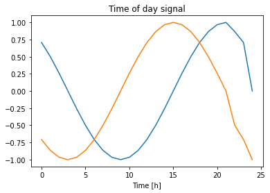

```python
plt.plot(np.array(df['Day sin'])[:25])
plt.plot(np.array(df['Day cos'])[:25])
plt.xlabel('Time [h]')
plt.title('Time of day signal')
```

```python
df.describe(include='all').T
```

|  | count | unique | top | freq | mean | std | min | 25% | 50% | 75% | max |
| --- | --- | --- | --- | --- | --- | --- | --- | --- | --- | --- | --- |
| holiday | 48204 | 12 | None | 48143 | NaN | NaN | NaN | NaN | NaN | NaN | NaN |
| temp | 48204 | NaN | NaN | NaN | 281.264 | 12.7083 | 243.39 | 272.19 | 282.45 | 291.806 | 310.07 |
| rain_1h | 48204 | NaN | NaN | NaN | 0.130315 | 1.00337 | 0 | 0 | 0 | 0 | 55.63 |
| snow_1h | 48204 | NaN | NaN | NaN | 0.000222388 | 0.00816761 | 0 | 0 | 0 | 0 | 0.51 |
| clouds_all | 48204 | NaN | NaN | NaN | 49.3622 | 39.0158 | 0 | 1 | 64 | 90 | 100 |
| weather_main | 48204 | 11 | Clouds | 15164 | NaN | NaN | NaN | NaN | NaN | NaN | NaN |
| weather_description | 48204 | 38 | sky is clear | 11665 | NaN | NaN | NaN | NaN | NaN | NaN | NaN |
| traffic_volume | 48204 | NaN | NaN | NaN | 3259.82 | 1986.86 | 0 | 1193 | 3380 | 4933 | 7280 |
| Day sin | 48204 | NaN | NaN | NaN | 0.0142834 | 0.70842 | -1 | -0.707107 | 1.52549e-12 | 0.707107 | 1 |
| Day cos | 48204 | NaN | NaN | NaN | 0.00663112 | 0.70563 | -1 | -0.707107 | 6.79096e-13 | 0.707107 | 1 |
| Year sin | 48204 | NaN | NaN | NaN | 0.0123169 | 0.697627 | -1 | -0.665969 | -0.00690973 | 0.70633 | 1 |
| Year cos | 48204 | NaN | NaN | NaN | -0.0317202 | 0.715667 | -1 | -0.744263 | -0.0921726 | 0.706604 | 1 |

### Encoding Categorical Variables

To utilize the categorical values, they must be converted to numerical representations. Because individual holidays are infrequent events (once a year), even with several years of data, there are likely too few occurences for the model to adequately pick up patterns specific to specific holidays. For that reason, holidays will be generalized and converted to a boolean, 1 if the sample occurs on a holiday, 0 otherwise. Weather_main and weather_description describe the same aspect of the data with different specificity. The Weather_main is more general. These two weather variables will be encoded using dummy variables. To avoid redundancy, 3 separate datasets will be developed. Two datasets using the dummy variables of either one of the weather features and one dataset that uses both. The performance of the baseline model on these datasets will determine which is used for model optimization.

#### Transforming: Holiday

```python
#Converting holiday to numerical attribute

#Non-holidays are encoded with a 0
df.loc[(df['holiday']== 'None'), 'holiday']= 0

#Holidays are encoded with a 1
df.loc[(df['holiday']!= 0), 'holiday']= 1

#The datatype for the holiday feature is converted to a float
df['holiday']= df['holiday'].astype('float64')
```

#### Creating 3 datasets

```python
#Removing weather_description
df_all = df.copy()

df_main = df.loc[:, df.columns!= 'weather_description'].copy()

df_desc = df.loc[:, df.columns!= 'weather_main'].copy()
```

```python
df_all.head()
```

|  | holiday | temp | rain_1h | snow_1h | clouds_all | weather_main | weather_description | traffic_volume | Day sin | Day cos | Year sin | Year cos |
| --- | --- | --- | --- | --- | --- | --- | --- | --- | --- | --- | --- | --- |
| 0 | 0.0 | 288.28 | 0.0 | 0.0 | 40 | Clouds | scattered clouds | 5545 | 7.071068e-01 | -0.707107 | -0.999766 | 0.021642 |
| 1 | 0.0 | 289.36 | 0.0 | 0.0 | 75 | Clouds | broken clouds | 4516 | 5.000000e-01 | -0.866025 | -0.999750 | 0.022358 |
| 2 | 0.0 | 289.58 | 0.0 | 0.0 | 90 | Clouds | overcast clouds | 4767 | 2.588190e-01 | -0.965926 | -0.999734 | 0.023075 |
| 3 | 0.0 | 290.13 | 0.0 | 0.0 | 90 | Clouds | overcast clouds | 5026 | 1.143105e-11 | -1.000000 | -0.999717 | 0.023791 |
| 4 | 0.0 | 291.14 | 0.0 | 0.0 | 75 | Clouds | broken clouds | 4918 | -2.588190e-01 | -0.965926 | -0.999700 | 0.024508 |

```python
df_main.head()
```

|  | holiday | temp | rain_1h | snow_1h | clouds_all | weather_main | traffic_volume | Day sin | Day cos | Year sin | Year cos |
| --- | --- | --- | --- | --- | --- | --- | --- | --- | --- | --- | --- |
| 0 | 0.0 | 288.28 | 0.0 | 0.0 | 40 | Clouds | 5545 | 7.071068e-01 | -0.707107 | -0.999766 | 0.021642 |
| 1 | 0.0 | 289.36 | 0.0 | 0.0 | 75 | Clouds | 4516 | 5.000000e-01 | -0.866025 | -0.999750 | 0.022358 |
| 2 | 0.0 | 289.58 | 0.0 | 0.0 | 90 | Clouds | 4767 | 2.588190e-01 | -0.965926 | -0.999734 | 0.023075 |
| 3 | 0.0 | 290.13 | 0.0 | 0.0 | 90 | Clouds | 5026 | 1.143105e-11 | -1.000000 | -0.999717 | 0.023791 |
| 4 | 0.0 | 291.14 | 0.0 | 0.0 | 75 | Clouds | 4918 | -2.588190e-01 | -0.965926 | -0.999700 | 0.024508 |

```python
df_desc.head()
```

|  | holiday | temp | rain_1h | snow_1h | clouds_all | weather_description | traffic_volume | Day sin | Day cos | Year sin | Year cos |
| --- | --- | --- | --- | --- | --- | --- | --- | --- | --- | --- | --- |
| 0 | 0.0 | 288.28 | 0.0 | 0.0 | 40 | scattered clouds | 5545 | 7.071068e-01 | -0.707107 | -0.999766 | 0.021642 |
| 1 | 0.0 | 289.36 | 0.0 | 0.0 | 75 | broken clouds | 4516 | 5.000000e-01 | -0.866025 | -0.999750 | 0.022358 |
| 2 | 0.0 | 289.58 | 0.0 | 0.0 | 90 | overcast clouds | 4767 | 2.588190e-01 | -0.965926 | -0.999734 | 0.023075 |
| 3 | 0.0 | 290.13 | 0.0 | 0.0 | 90 | overcast clouds | 5026 | 1.143105e-11 | -1.000000 | -0.999717 | 0.023791 |
| 4 | 0.0 | 291.14 | 0.0 | 0.0 | 75 | broken clouds | 4918 | -2.588190e-01 | -0.965926 | -0.999700 | 0.024508 |

#### Creating Dummy Variables

```python
#Creating dummy variables for df_all (weather_main and weather_description)
df_all= pd.get_dummies(df_all, columns= ['weather_main', 'weather_description'])

df_main= pd.get_dummies(df_main, columns= ['weather_main'])

df_desc= pd.get_dummies(df_desc, columns= ['weather_description'])
```

```python
df_all.columns
```

```
Index(['holiday', 'temp', 'rain_1h', 'snow_1h', 'clouds_all', 'traffic_volume',
       'Day sin', 'Day cos', 'Year sin', 'Year cos', 'weather_main_Clear',
       'weather_main_Clouds', 'weather_main_Drizzle', 'weather_main_Fog',
       'weather_main_Haze', 'weather_main_Mist', 'weather_main_Rain',
       'weather_main_Smoke', 'weather_main_Snow', 'weather_main_Squall',
       'weather_main_Thunderstorm', 'weather_description_SQUALLS',
       'weather_description_Sky is Clear', 'weather_description_broken clouds',
       'weather_description_drizzle', 'weather_description_few clouds',
       'weather_description_fog', 'weather_description_freezing rain',
       'weather_description_haze',
       'weather_description_heavy intensity drizzle',
       'weather_description_heavy intensity rain',
       'weather_description_heavy snow',
       'weather_description_light intensity drizzle',
       'weather_description_light intensity shower rain',
       'weather_description_light rain',
       'weather_description_light rain and snow',
       'weather_description_light shower snow',
       'weather_description_light snow', 'weather_description_mist',
       'weather_description_moderate rain',
       'weather_description_overcast clouds',
       'weather_description_proximity shower rain',
       'weather_description_proximity thunderstorm',
       'weather_description_proximity thunderstorm with drizzle',
       'weather_description_proximity thunderstorm with rain',
       'weather_description_scattered clouds',
       'weather_description_shower drizzle', 'weather_description_shower snow',
       'weather_description_sky is clear', 'weather_description_sleet',
       'weather_description_smoke', 'weather_description_snow',
       'weather_description_thunderstorm',
       'weather_description_thunderstorm with drizzle',
       'weather_description_thunderstorm with heavy rain',
       'weather_description_thunderstorm with light drizzle',
       'weather_description_thunderstorm with light rain',
       'weather_description_thunderstorm with rain',
       'weather_description_very heavy rain'],
      dtype='object')
```

```python
df_main.columns
```

```
Index(['holiday', 'temp', 'rain_1h', 'snow_1h', 'clouds_all', 'traffic_volume',
       'Day sin', 'Day cos', 'Year sin', 'Year cos', 'weather_main_Clear',
       'weather_main_Clouds', 'weather_main_Drizzle', 'weather_main_Fog',
       'weather_main_Haze', 'weather_main_Mist', 'weather_main_Rain',
       'weather_main_Smoke', 'weather_main_Snow', 'weather_main_Squall',
       'weather_main_Thunderstorm'],
      dtype='object')
```

```python
df_desc.columns
```

```
Index(['holiday', 'temp', 'rain_1h', 'snow_1h', 'clouds_all', 'traffic_volume',
       'Day sin', 'Day cos', 'Year sin', 'Year cos',
       'weather_description_SQUALLS', 'weather_description_Sky is Clear',
       'weather_description_broken clouds', 'weather_description_drizzle',
       'weather_description_few clouds', 'weather_description_fog',
       'weather_description_freezing rain', 'weather_description_haze',
       'weather_description_heavy intensity drizzle',
       'weather_description_heavy intensity rain',
       'weather_description_heavy snow',
       'weather_description_light intensity drizzle',
       'weather_description_light intensity shower rain',
       'weather_description_light rain',
       'weather_description_light rain and snow',
       'weather_description_light shower snow',
       'weather_description_light snow', 'weather_description_mist',
       'weather_description_moderate rain',
       'weather_description_overcast clouds',
       'weather_description_proximity shower rain',
       'weather_description_proximity thunderstorm',
       'weather_description_proximity thunderstorm with drizzle',
       'weather_description_proximity thunderstorm with rain',
       'weather_description_scattered clouds',
       'weather_description_shower drizzle', 'weather_description_shower snow',
       'weather_description_sky is clear', 'weather_description_sleet',
       'weather_description_smoke', 'weather_description_snow',
       'weather_description_thunderstorm',
       'weather_description_thunderstorm with drizzle',
       'weather_description_thunderstorm with heavy rain',
       'weather_description_thunderstorm with light drizzle',
       'weather_description_thunderstorm with light rain',
       'weather_description_thunderstorm with rain',
       'weather_description_very heavy rain'],
      dtype='object')
```

### Spliting the data: Train, Validation, Test

The last 5000 samples will be used as a test set. The other records will have a trainin-test split of 80-20

Note the data is **not** being randomly shuffled before splitting. This is for two reasons.

1. It ensures that chopping the data into windows of consecutive samples is still possible.
2. It ensures that the validation/test results are more realistic, being evaluated on data collected after the model was trained.

#### Splitting df_all

```python
#Splitting df_all dataset
#Test data
test_df_all= df_all[-5000:]
print(len(test_df_all))

#Trainining and validation data
n= len(df_all) - 5000
train_df_all= df_all[0:int(n*.8)]
print(len(train_df_all))
val_df_all= df_all[int(n*.8):-5000]
print(len(val_df_all))
```

```
5000
34563
8641
```

#### Splitting df_main

```python
#Splitting df_main dataset
#Test data
test_df_main= df_main[-5000:]
print(len(test_df_main))

#Trainining and validation data
n= len(df_main) - 5000
train_df_main= df_main[0:int(n*.8)]
print(len(train_df_main))
val_df_main= df_main[int(n*.8):-5000]
print(len(val_df_main))
```

```
5000
34563
8641
```

#### Splitting df_desc

```python
#Splitting df_desc dataset
#Test data
test_df_desc= df_desc[-5000:]
print(len(test_df_desc))

#Trainining and validation data
n= len(df_desc) - 5000
train_df_desc= df_desc[0:int(n*.8)]
print(len(train_df_desc))
val_df_desc= df_desc[int(n*.8):-5000]
print(len(val_df_desc))
```

```
5000
34563
8641
```

### Normalize the data: Min-Max (0,1)

It is important to scale features before training a neural network so that no variable has outsized influence on the model due to its scale of measurement. The tutorial originally used z-score normalization to address this issue, however, we are using different data here and that form of normalization works best on data that largely follows a gaussian distribution, which this data decidedly does not. The traffic data contains many categorical variables encoded by 0 or 1 and are not evenly distributed. As a result, this technique may still produce a diffference in scale between variables that we do not want. For this reason, a min-max scaling technique will be used instead, condensing values into a range between 0 and 1. To implement min-max scaling, the minimum variable value is subtracted from the value and the result is divided by the range (max - min) of that variable to produce the normalized value. Normalization was not applied to the time of day/year variables in order to maintain their integrity and because they already exist at an acceptable scale.

Similarly to the tutorial, only the training data will be used to scale the data. This is to ensure that model does not inadvertantly pick up information about the validation and test data during training.

```python
#Example of the problem with z-normalization
train_df_all['weather_main_Squall'].describe().T
```

```
count    34563.000000
mean         0.000116
std          0.010757
min          0.000000
25%          0.000000
50%          0.000000
75%          0.000000
max          1.000000
Name: weather_main_Squall, dtype: float64
```

As you can see above, the mean and standard deviation for this variable are very small compared to its maximum value. Using a z-score normalization will produce a normalized value a degree or more larger than some other variables. This would not adequately address differences in scale between the variables.

#### Normalization: df_all

```python
#Applying min-max scaling to df_all (except for time of day signals)
#Collecting all non-time of day columns
norm_cols= [c for c in train_df_all.columns if c not in ['Day sin', 'Day cos', 'Year sin', 'Year cos']]

#Collecting min, max, and range values for each variable
train_min= train_df_all.loc[:, norm_cols].min()
train_max= train_df_all.loc[:, norm_cols].max()
mm_range= train_max - train_min

#Applying min-max scaling to the data
train_df_all.loc[:, norm_cols]= (train_df_all.loc[:, norm_cols] - train_min) / mm_range
val_df_all.loc[:, norm_cols]= (val_df_all.loc[:, norm_cols] - train_min) / mm_range
test_df_all.loc[:, norm_cols]= (test_df_all.loc[:, norm_cols] - train_min) / mm_range
```

```python
train_df_all.describe().T
```

|  | count | mean | std | min | 25% | 50% | 75% | max |
| --- | --- | --- | --- | --- | --- | --- | --- | --- |
| holiday | 34563.0 | 0.001273 | 0.035657 | 0.0 | 0.000000 | 0.000000e+00 | 0.000000 | 1.0 |
| temp | 34563.0 | 0.570582 | 0.192931 | 0.0 | 0.440247 | 5.751735e-01 | 0.731072 | 1.0 |
| rain_1h | 34563.0 | 0.002764 | 0.020583 | 0.0 | 0.000000 | 0.000000e+00 | 0.000000 | 1.0 |
| snow_1h | 34563.0 | 0.000608 | 0.018910 | 0.0 | 0.000000 | 0.000000e+00 | 0.000000 | 1.0 |
| clouds_all | 34563.0 | 0.503321 | 0.388854 | 0.0 | 0.010000 | 6.400000e-01 | 0.900000 | 1.0 |
| traffic_volume | 34563.0 | 0.445231 | 0.273336 | 0.0 | 0.160302 | 4.586538e-01 | 0.676374 | 1.0 |
| Day sin | 34563.0 | 0.013655 | 0.707767 | -1.0 | -0.707107 | 1.371679e-12 | 0.707107 | 1.0 |
| Day cos | 34563.0 | 0.008647 | 0.706282 | -1.0 | -0.707107 | 8.958190e-13 | 0.707107 | 1.0 |
| Year sin | 34563.0 | 0.066763 | 0.693700 | -1.0 | -0.589551 | 9.428864e-02 | 0.750701 | 1.0 |
| Year cos | 34563.0 | 0.019179 | 0.716927 | -1.0 | -0.706000 | 3.276184e-02 | 0.756193 | 1.0 |
| weather_main_Clear | 34563.0 | 0.275381 | 0.446713 | 0.0 | 0.000000 | 0.000000e+00 | 1.000000 | 1.0 |
| weather_main_Clouds | 34563.0 | 0.330961 | 0.470566 | 0.0 | 0.000000 | 0.000000e+00 | 1.000000 | 1.0 |
| weather_main_Drizzle | 34563.0 | 0.036658 | 0.187923 | 0.0 | 0.000000 | 0.000000e+00 | 0.000000 | 1.0 |
| weather_main_Fog | 34563.0 | 0.016752 | 0.128343 | 0.0 | 0.000000 | 0.000000e+00 | 0.000000 | 1.0 |
| weather_main_Haze | 34563.0 | 0.026358 | 0.160199 | 0.0 | 0.000000 | 0.000000e+00 | 0.000000 | 1.0 |
| weather_main_Mist | 34563.0 | 0.119145 | 0.323963 | 0.0 | 0.000000 | 0.000000e+00 | 0.000000 | 1.0 |
| weather_main_Rain | 34563.0 | 0.117553 | 0.322083 | 0.0 | 0.000000 | 0.000000e+00 | 0.000000 | 1.0 |
| weather_main_Smoke | 34563.0 | 0.000492 | 0.022173 | 0.0 | 0.000000 | 0.000000e+00 | 0.000000 | 1.0 |
| weather_main_Snow | 34563.0 | 0.059891 | 0.237288 | 0.0 | 0.000000 | 0.000000e+00 | 0.000000 | 1.0 |
| weather_main_Squall | 34563.0 | 0.000116 | 0.010757 | 0.0 | 0.000000 | 0.000000e+00 | 0.000000 | 1.0 |
| weather_main_Thunderstorm | 34563.0 | 0.016694 | 0.128125 | 0.0 | 0.000000 | 0.000000e+00 | 0.000000 | 1.0 |
| weather_description_SQUALLS | 34563.0 | 0.000116 | 0.010757 | 0.0 | 0.000000 | 0.000000e+00 | 0.000000 | 1.0 |
| weather_description_Sky is Clear | 34563.0 | 0.049446 | 0.216800 | 0.0 | 0.000000 | 0.000000e+00 | 0.000000 | 1.0 |
| weather_description_broken clouds | 34563.0 | 0.099586 | 0.299452 | 0.0 | 0.000000 | 0.000000e+00 | 0.000000 | 1.0 |
| weather_description_drizzle | 34563.0 | 0.013974 | 0.117387 | 0.0 | 0.000000 | 0.000000e+00 | 0.000000 | 1.0 |
| weather_description_few clouds | 34563.0 | 0.045714 | 0.208866 | 0.0 | 0.000000 | 0.000000e+00 | 0.000000 | 1.0 |
| weather_description_fog | 34563.0 | 0.016752 | 0.128343 | 0.0 | 0.000000 | 0.000000e+00 | 0.000000 | 1.0 |
| weather_description_freezing rain | 34563.0 | 0.000058 | 0.007607 | 0.0 | 0.000000 | 0.000000e+00 | 0.000000 | 1.0 |
| weather_description_haze | 34563.0 | 0.026358 | 0.160199 | 0.0 | 0.000000 | 0.000000e+00 | 0.000000 | 1.0 |
| weather_description_heavy intensity drizzle | 34563.0 | 0.001360 | 0.036851 | 0.0 | 0.000000 | 0.000000e+00 | 0.000000 | 1.0 |
| weather_description_heavy intensity rain | 34563.0 | 0.009403 | 0.096514 | 0.0 | 0.000000 | 0.000000e+00 | 0.000000 | 1.0 |
| weather_description_heavy snow | 34563.0 | 0.016983 | 0.129211 | 0.0 | 0.000000 | 0.000000e+00 | 0.000000 | 1.0 |
| weather_description_light intensity drizzle | 34563.0 | 0.021294 | 0.144366 | 0.0 | 0.000000 | 0.000000e+00 | 0.000000 | 1.0 |
| weather_description_light intensity shower rain | 34563.0 | 0.000289 | 0.017007 | 0.0 | 0.000000 | 0.000000e+00 | 0.000000 | 1.0 |
| weather_description_light rain | 34563.0 | 0.072708 | 0.259660 | 0.0 | 0.000000 | 0.000000e+00 | 0.000000 | 1.0 |
| weather_description_light rain and snow | 34563.0 | 0.000174 | 0.013175 | 0.0 | 0.000000 | 0.000000e+00 | 0.000000 | 1.0 |
| weather_description_light shower snow | 34563.0 | 0.000116 | 0.010757 | 0.0 | 0.000000 | 0.000000e+00 | 0.000000 | 1.0 |
| weather_description_light snow | 34563.0 | 0.037034 | 0.188847 | 0.0 | 0.000000 | 0.000000e+00 | 0.000000 | 1.0 |
| weather_description_mist | 34563.0 | 0.119145 | 0.323963 | 0.0 | 0.000000 | 0.000000e+00 | 0.000000 | 1.0 |
| weather_description_moderate rain | 34563.0 | 0.032896 | 0.178368 | 0.0 | 0.000000 | 0.000000e+00 | 0.000000 | 1.0 |
| weather_description_overcast clouds | 34563.0 | 0.116628 | 0.320981 | 0.0 | 0.000000 | 0.000000e+00 | 0.000000 | 1.0 |
| weather_description_proximity shower rain | 34563.0 | 0.001678 | 0.040931 | 0.0 | 0.000000 | 0.000000e+00 | 0.000000 | 1.0 |
| weather_description_proximity thunderstorm | 34563.0 | 0.010560 | 0.102221 | 0.0 | 0.000000 | 0.000000e+00 | 0.000000 | 1.0 |
| weather_description_proximity thunderstorm with drizzle | 34563.0 | 0.000318 | 0.017837 | 0.0 | 0.000000 | 0.000000e+00 | 0.000000 | 1.0 |
| weather_description_proximity thunderstorm with rain | 34563.0 | 0.000752 | 0.027417 | 0.0 | 0.000000 | 0.000000e+00 | 0.000000 | 1.0 |
| weather_description_scattered clouds | 34563.0 | 0.069033 | 0.253515 | 0.0 | 0.000000 | 0.000000e+00 | 0.000000 | 1.0 |
| weather_description_shower drizzle | 34563.0 | 0.000029 | 0.005379 | 0.0 | 0.000000 | 0.000000e+00 | 0.000000 | 1.0 |
| weather_description_shower snow | 34563.0 | 0.000029 | 0.005379 | 0.0 | 0.000000 | 0.000000e+00 | 0.000000 | 1.0 |
| weather_description_sky is clear | 34563.0 | 0.225935 | 0.418203 | 0.0 | 0.000000 | 0.000000e+00 | 0.000000 | 1.0 |
| weather_description_sleet | 34563.0 | 0.000058 | 0.007607 | 0.0 | 0.000000 | 0.000000e+00 | 0.000000 | 1.0 |
| weather_description_smoke | 34563.0 | 0.000492 | 0.022173 | 0.0 | 0.000000 | 0.000000e+00 | 0.000000 | 1.0 |
| weather_description_snow | 34563.0 | 0.005497 | 0.073940 | 0.0 | 0.000000 | 0.000000e+00 | 0.000000 | 1.0 |
| weather_description_thunderstorm | 34563.0 | 0.001967 | 0.044313 | 0.0 | 0.000000 | 0.000000e+00 | 0.000000 | 1.0 |
| weather_description_thunderstorm with drizzle | 34563.0 | 0.000058 | 0.007607 | 0.0 | 0.000000 | 0.000000e+00 | 0.000000 | 1.0 |
| weather_description_thunderstorm with heavy rain | 34563.0 | 0.001215 | 0.034839 | 0.0 | 0.000000 | 0.000000e+00 | 0.000000 | 1.0 |
| weather_description_thunderstorm with light drizzle | 34563.0 | 0.000116 | 0.010757 | 0.0 | 0.000000 | 0.000000e+00 | 0.000000 | 1.0 |
| weather_description_thunderstorm with light rain | 34563.0 | 0.001013 | 0.031806 | 0.0 | 0.000000 | 0.000000e+00 | 0.000000 | 1.0 |
| weather_description_thunderstorm with rain | 34563.0 | 0.000694 | 0.026342 | 0.0 | 0.000000 | 0.000000e+00 | 0.000000 | 1.0 |
| weather_description_very heavy rain | 34563.0 | 0.000521 | 0.022815 | 0.0 | 0.000000 | 0.000000e+00 | 0.000000 | 1.0 |

#### Normalization: df_main

```python
#Applying min-max scaling to df_main (except for time of day signals)
#Collecting all non-time of day columns
norm_cols= [c for c in train_df_main.columns if c not in ['Day sin', 'Day cos', 'Year sin', 'Year cos']]

#Collecting min, max, and range values for each variable
train_min= train_df_main.loc[:, norm_cols].min()
train_max= train_df_main.loc[:, norm_cols].max()
mm_range= train_max - train_min

#Applying min-max scaling to the data
train_df_main.loc[:, norm_cols]= (train_df_main.loc[:, norm_cols] - train_min) / mm_range
val_df_main.loc[:, norm_cols]= (val_df_main.loc[:, norm_cols] - train_min) / mm_range
test_df_main.loc[:, norm_cols]= (test_df_main.loc[:, norm_cols] - train_min) / mm_range
```

```python
train_df_main.describe().T
```

|  | count | mean | std | min | 25% | 50% | 75% | max |
| --- | --- | --- | --- | --- | --- | --- | --- | --- |
| holiday | 34563.0 | 0.001273 | 0.035657 | 0.0 | 0.000000 | 0.000000e+00 | 0.000000 | 1.0 |
| temp | 34563.0 | 0.570582 | 0.192931 | 0.0 | 0.440247 | 5.751735e-01 | 0.731072 | 1.0 |
| rain_1h | 34563.0 | 0.002764 | 0.020583 | 0.0 | 0.000000 | 0.000000e+00 | 0.000000 | 1.0 |
| snow_1h | 34563.0 | 0.000608 | 0.018910 | 0.0 | 0.000000 | 0.000000e+00 | 0.000000 | 1.0 |
| clouds_all | 34563.0 | 0.503321 | 0.388854 | 0.0 | 0.010000 | 6.400000e-01 | 0.900000 | 1.0 |
| traffic_volume | 34563.0 | 0.445231 | 0.273336 | 0.0 | 0.160302 | 4.586538e-01 | 0.676374 | 1.0 |
| Day sin | 34563.0 | 0.013655 | 0.707767 | -1.0 | -0.707107 | 1.371679e-12 | 0.707107 | 1.0 |
| Day cos | 34563.0 | 0.008647 | 0.706282 | -1.0 | -0.707107 | 8.958190e-13 | 0.707107 | 1.0 |
| Year sin | 34563.0 | 0.066763 | 0.693700 | -1.0 | -0.589551 | 9.428864e-02 | 0.750701 | 1.0 |
| Year cos | 34563.0 | 0.019179 | 0.716927 | -1.0 | -0.706000 | 3.276184e-02 | 0.756193 | 1.0 |
| weather_main_Clear | 34563.0 | 0.275381 | 0.446713 | 0.0 | 0.000000 | 0.000000e+00 | 1.000000 | 1.0 |
| weather_main_Clouds | 34563.0 | 0.330961 | 0.470566 | 0.0 | 0.000000 | 0.000000e+00 | 1.000000 | 1.0 |
| weather_main_Drizzle | 34563.0 | 0.036658 | 0.187923 | 0.0 | 0.000000 | 0.000000e+00 | 0.000000 | 1.0 |
| weather_main_Fog | 34563.0 | 0.016752 | 0.128343 | 0.0 | 0.000000 | 0.000000e+00 | 0.000000 | 1.0 |
| weather_main_Haze | 34563.0 | 0.026358 | 0.160199 | 0.0 | 0.000000 | 0.000000e+00 | 0.000000 | 1.0 |
| weather_main_Mist | 34563.0 | 0.119145 | 0.323963 | 0.0 | 0.000000 | 0.000000e+00 | 0.000000 | 1.0 |
| weather_main_Rain | 34563.0 | 0.117553 | 0.322083 | 0.0 | 0.000000 | 0.000000e+00 | 0.000000 | 1.0 |
| weather_main_Smoke | 34563.0 | 0.000492 | 0.022173 | 0.0 | 0.000000 | 0.000000e+00 | 0.000000 | 1.0 |
| weather_main_Snow | 34563.0 | 0.059891 | 0.237288 | 0.0 | 0.000000 | 0.000000e+00 | 0.000000 | 1.0 |
| weather_main_Squall | 34563.0 | 0.000116 | 0.010757 | 0.0 | 0.000000 | 0.000000e+00 | 0.000000 | 1.0 |
| weather_main_Thunderstorm | 34563.0 | 0.016694 | 0.128125 | 0.0 | 0.000000 | 0.000000e+00 | 0.000000 | 1.0 |

#### Normalization: df_desc

```python
#Applying min-max scaling to df_desc (except for time of day signals)
#Collecting all non-time of day columns
norm_cols= [c for c in train_df_desc.columns if c not in ['Day sin', 'Day cos', 'Year sin', 'Year cos']]

#Collecting min, max, and range values for each variable
train_min= train_df_desc.loc[:, norm_cols].min()
train_max= train_df_desc.loc[:, norm_cols].max()
mm_range= train_max - train_min

#Applying min-max scaling to the data
train_df_desc.loc[:, norm_cols]= (train_df_desc.loc[:, norm_cols] - train_min) / mm_range
val_df_desc.loc[:, norm_cols]= (val_df_desc.loc[:, norm_cols] - train_min) / mm_range
test_df_desc.loc[:, norm_cols]= (test_df_desc.loc[:, norm_cols] - train_min) / mm_range
```

```python
train_df_desc.describe().T
```

|  | count | mean | std | min | 25% | 50% | 75% | max |
| --- | --- | --- | --- | --- | --- | --- | --- | --- |
| holiday | 34563.0 | 0.001273 | 0.035657 | 0.0 | 0.000000 | 0.000000e+00 | 0.000000 | 1.0 |
| temp | 34563.0 | 0.570582 | 0.192931 | 0.0 | 0.440247 | 5.751735e-01 | 0.731072 | 1.0 |
| rain_1h | 34563.0 | 0.002764 | 0.020583 | 0.0 | 0.000000 | 0.000000e+00 | 0.000000 | 1.0 |
| snow_1h | 34563.0 | 0.000608 | 0.018910 | 0.0 | 0.000000 | 0.000000e+00 | 0.000000 | 1.0 |
| clouds_all | 34563.0 | 0.503321 | 0.388854 | 0.0 | 0.010000 | 6.400000e-01 | 0.900000 | 1.0 |
| traffic_volume | 34563.0 | 0.445231 | 0.273336 | 0.0 | 0.160302 | 4.586538e-01 | 0.676374 | 1.0 |
| Day sin | 34563.0 | 0.013655 | 0.707767 | -1.0 | -0.707107 | 1.371679e-12 | 0.707107 | 1.0 |
| Day cos | 34563.0 | 0.008647 | 0.706282 | -1.0 | -0.707107 | 8.958190e-13 | 0.707107 | 1.0 |
| Year sin | 34563.0 | 0.066763 | 0.693700 | -1.0 | -0.589551 | 9.428864e-02 | 0.750701 | 1.0 |
| Year cos | 34563.0 | 0.019179 | 0.716927 | -1.0 | -0.706000 | 3.276184e-02 | 0.756193 | 1.0 |
| weather_description_SQUALLS | 34563.0 | 0.000116 | 0.010757 | 0.0 | 0.000000 | 0.000000e+00 | 0.000000 | 1.0 |
| weather_description_Sky is Clear | 34563.0 | 0.049446 | 0.216800 | 0.0 | 0.000000 | 0.000000e+00 | 0.000000 | 1.0 |
| weather_description_broken clouds | 34563.0 | 0.099586 | 0.299452 | 0.0 | 0.000000 | 0.000000e+00 | 0.000000 | 1.0 |
| weather_description_drizzle | 34563.0 | 0.013974 | 0.117387 | 0.0 | 0.000000 | 0.000000e+00 | 0.000000 | 1.0 |
| weather_description_few clouds | 34563.0 | 0.045714 | 0.208866 | 0.0 | 0.000000 | 0.000000e+00 | 0.000000 | 1.0 |
| weather_description_fog | 34563.0 | 0.016752 | 0.128343 | 0.0 | 0.000000 | 0.000000e+00 | 0.000000 | 1.0 |
| weather_description_freezing rain | 34563.0 | 0.000058 | 0.007607 | 0.0 | 0.000000 | 0.000000e+00 | 0.000000 | 1.0 |
| weather_description_haze | 34563.0 | 0.026358 | 0.160199 | 0.0 | 0.000000 | 0.000000e+00 | 0.000000 | 1.0 |
| weather_description_heavy intensity drizzle | 34563.0 | 0.001360 | 0.036851 | 0.0 | 0.000000 | 0.000000e+00 | 0.000000 | 1.0 |
| weather_description_heavy intensity rain | 34563.0 | 0.009403 | 0.096514 | 0.0 | 0.000000 | 0.000000e+00 | 0.000000 | 1.0 |
| weather_description_heavy snow | 34563.0 | 0.016983 | 0.129211 | 0.0 | 0.000000 | 0.000000e+00 | 0.000000 | 1.0 |
| weather_description_light intensity drizzle | 34563.0 | 0.021294 | 0.144366 | 0.0 | 0.000000 | 0.000000e+00 | 0.000000 | 1.0 |
| weather_description_light intensity shower rain | 34563.0 | 0.000289 | 0.017007 | 0.0 | 0.000000 | 0.000000e+00 | 0.000000 | 1.0 |
| weather_description_light rain | 34563.0 | 0.072708 | 0.259660 | 0.0 | 0.000000 | 0.000000e+00 | 0.000000 | 1.0 |
| weather_description_light rain and snow | 34563.0 | 0.000174 | 0.013175 | 0.0 | 0.000000 | 0.000000e+00 | 0.000000 | 1.0 |
| weather_description_light shower snow | 34563.0 | 0.000116 | 0.010757 | 0.0 | 0.000000 | 0.000000e+00 | 0.000000 | 1.0 |
| weather_description_light snow | 34563.0 | 0.037034 | 0.188847 | 0.0 | 0.000000 | 0.000000e+00 | 0.000000 | 1.0 |
| weather_description_mist | 34563.0 | 0.119145 | 0.323963 | 0.0 | 0.000000 | 0.000000e+00 | 0.000000 | 1.0 |
| weather_description_moderate rain | 34563.0 | 0.032896 | 0.178368 | 0.0 | 0.000000 | 0.000000e+00 | 0.000000 | 1.0 |
| weather_description_overcast clouds | 34563.0 | 0.116628 | 0.320981 | 0.0 | 0.000000 | 0.000000e+00 | 0.000000 | 1.0 |
| weather_description_proximity shower rain | 34563.0 | 0.001678 | 0.040931 | 0.0 | 0.000000 | 0.000000e+00 | 0.000000 | 1.0 |
| weather_description_proximity thunderstorm | 34563.0 | 0.010560 | 0.102221 | 0.0 | 0.000000 | 0.000000e+00 | 0.000000 | 1.0 |
| weather_description_proximity thunderstorm with drizzle | 34563.0 | 0.000318 | 0.017837 | 0.0 | 0.000000 | 0.000000e+00 | 0.000000 | 1.0 |
| weather_description_proximity thunderstorm with rain | 34563.0 | 0.000752 | 0.027417 | 0.0 | 0.000000 | 0.000000e+00 | 0.000000 | 1.0 |
| weather_description_scattered clouds | 34563.0 | 0.069033 | 0.253515 | 0.0 | 0.000000 | 0.000000e+00 | 0.000000 | 1.0 |
| weather_description_shower drizzle | 34563.0 | 0.000029 | 0.005379 | 0.0 | 0.000000 | 0.000000e+00 | 0.000000 | 1.0 |
| weather_description_shower snow | 34563.0 | 0.000029 | 0.005379 | 0.0 | 0.000000 | 0.000000e+00 | 0.000000 | 1.0 |
| weather_description_sky is clear | 34563.0 | 0.225935 | 0.418203 | 0.0 | 0.000000 | 0.000000e+00 | 0.000000 | 1.0 |
| weather_description_sleet | 34563.0 | 0.000058 | 0.007607 | 0.0 | 0.000000 | 0.000000e+00 | 0.000000 | 1.0 |
| weather_description_smoke | 34563.0 | 0.000492 | 0.022173 | 0.0 | 0.000000 | 0.000000e+00 | 0.000000 | 1.0 |
| weather_description_snow | 34563.0 | 0.005497 | 0.073940 | 0.0 | 0.000000 | 0.000000e+00 | 0.000000 | 1.0 |
| weather_description_thunderstorm | 34563.0 | 0.001967 | 0.044313 | 0.0 | 0.000000 | 0.000000e+00 | 0.000000 | 1.0 |
| weather_description_thunderstorm with drizzle | 34563.0 | 0.000058 | 0.007607 | 0.0 | 0.000000 | 0.000000e+00 | 0.000000 | 1.0 |
| weather_description_thunderstorm with heavy rain | 34563.0 | 0.001215 | 0.034839 | 0.0 | 0.000000 | 0.000000e+00 | 0.000000 | 1.0 |
| weather_description_thunderstorm with light drizzle | 34563.0 | 0.000116 | 0.010757 | 0.0 | 0.000000 | 0.000000e+00 | 0.000000 | 1.0 |
| weather_description_thunderstorm with light rain | 34563.0 | 0.001013 | 0.031806 | 0.0 | 0.000000 | 0.000000e+00 | 0.000000 | 1.0 |
| weather_description_thunderstorm with rain | 34563.0 | 0.000694 | 0.026342 | 0.0 | 0.000000 | 0.000000e+00 | 0.000000 | 1.0 |
| weather_description_very heavy rain | 34563.0 | 0.000521 | 0.022815 | 0.0 | 0.000000 | 0.000000e+00 | 0.000000 | 1.0 |